# Clean Welch regen data

Carmen

3/5/2020

# Load data

## Welch data

```r
tree <- read_excel("~/Shrubs-Seedlings/data/Data_for_shrub_growth/Welch_data/tree_regen_RegenDatabase_1_13_16_updatedDates.xlsx")
load(file = "~/Shrubs-Seedlings/compiled_data/shrub_growth/Welch_df.Rdata")
```

# Clean tree data

## Remove unnecessary columns

```r
tree <- tree %>%
  dplyr::select(ID, Regen_Plot, Count_total, Type, Species, num_dead, seed_veg_plant, tallest_age, tallest_ht_cm, tallest_lastyr_cm, Remarks, number_sprouts)
```

## Combine with previously cleaned Welch data with info on shrubs

```r
df <- left_join(df, tree, by = "Regen_Plot")
```

```r
welch_all <- df
```

## Filter to American River Complex

```r
df <- df %>%
  filter(Fire == "AMERICAN RIVER")
```

```r
welch <- df
remove(df)
```

# Look at the shrubs

```r
welch %>%
  group_by(Shrub_species) %>%
  count()
```

```
## # A tibble: 10 x 2
## # Groups:   Shrub_species [10]
##    Shrub_species     n
##    <chr>         <int>
##  1 ARNE              2
##  2 ARPA6            24
##  3 CECO             25
##  4 CEIN3             4
##  5 CEPR              2
##  6 CHSE11           10
##  7 PREM              3
##  8 QUVA             17
##  9 RIBES             7
## 10 SYMO              1
```

## Compare that to my data

### Load my data

```r
load(file="~/Shrubs-Seedlings/compiled_data/fire_footprints/master_seedlings_vert.Rdata")
me <- df %>%
  dplyr::select(Sdlg, Species, Cov1.3, Ht1.3, ShrubSpp03, shrubarea3, BasDia2016.cm, Ht2016.cm_spring, heatload, incidrad, Slope.Deg, Elevation, Fire, Years, Year) %>%
  filter(Fire == "AMRC") %>%
  filter(Year==2016) %>%
  mutate(Cov_prop = Cov1.3/1200) %>%
  distinct() %>%
  droplevels()
```

```r
me_shrspp <- me %>%
  filter(Species %in% c("PIPO", "ABCO")) %>%
  group_by(Species, ShrubSpp03) %>%
  summarize(sum = n()) %>%
  ungroup() %>%
  group_by(Species) %>%
  mutate(prop = sum/sum(sum)) %>%
  #filter(ShrubSpp03 %in% c("ARPA", "CECO", "CHSE")) %>%
  ggplot()+
  geom_col(aes(x = Species, y = prop, fill = ShrubSpp03), position = "dodge")+
  theme_minimal()+
  ylim(c(0, 0.7))+
  ggtitle("My data")
```

```r
me %>%
  filter(Species %in% c("PIPO", "ABCO")) %>%
  group_by(Species, ShrubSpp03) %>%
  summarize(sum = n()) %>%
  filter(ShrubSpp03 %in% c("ARPA", "CECO", "CEIN")) %>%
  ungroup() %>%
  summarize(sum(sum))
```

```
## # A tibble: 1 x 1
##   `sum(sum)`
##        <int>
## 1         79
```

# Calculate proportion within each shrub cover for each conifer species in Welch data, limiting to the species I found in AMRC

## Follow one set of plots to make sure I’m doing it right

```r
welch %>%
  filter(Shrub_species == "ARPA6" & Species == "ABCO") %>%
  select(Regen_Plot, Species, Shrub_species, Count_total, Cover, modal_ht_cm)
```

```
## # A tibble: 6 x 6
##   Regen_Plot Species Shrub_species Count_total Cover modal_ht_cm
##   <chr>      <chr>   <chr>               <dbl> <dbl>       <dbl>
## 1 AMR1300196 ABCO    ARPA6                   1     5          43
## 2 AMR1300253 ABCO    ARPA6                   6    15          80
## 3 AMR1300264 ABCO    ARPA6                   1     2          45
## 4 AMR1300268 ABCO    ARPA6                   1    10          70
## 5 AMR1300312 ABCO    ARPA6                  20    30          55
## 6 AMR1300443 ABCO    ARPA6                   1    40          60
```

## Restructure data so that there’s only one row per tree species per regen plot

Choose the dominant shrub species by choosing highest shrub cover, then highest shrubarea

```r
welch_shrspp <- welch %>%
  ungroup() %>%
  group_by(Regen_Plot) %>%
  filter(Cover == max(Cover)) %>%
  mutate(shrubarea = Cover*modal_ht_cm) %>%
  group_by(Regen_Plot) %>%
  filter(shrubarea == max(shrubarea)) %>%
  dplyr::select(Regen_Plot, Shrub_species, Species, Cover, modal_ht_cm, Fire, Count_total)
welch_shrspp
```

```
## # A tibble: 31 x 7
## # Groups:   Regen_Plot [15]
##    Regen_Plot Shrub_species Species Cover modal_ht_cm Fire           Count_total
##    <chr>      <chr>         <chr>   <dbl>       <dbl> <chr>                <dbl>
##  1 AMR1300156 CECO          PILA        5          30 AMERICAN RIVER           6
##  2 AMR1300156 CECO          ABMA        5          30 AMERICAN RIVER           4
##  3 AMR1300156 CECO          ABCO        5          30 AMERICAN RIVER           3
##  4 AMR1300192 QUVA          PIPO        2          15 AMERICAN RIVER           1
##  5 AMR1300192 QUVA          ABMA        2          15 AMERICAN RIVER           2
##  6 AMR1300196 CECO          PSME       20          65 AMERICAN RIVER           4
##  7 AMR1300196 CECO          ABCO       20          65 AMERICAN RIVER           1
##  8 AMR1300247 CHSE11        PIPO        1          50 AMERICAN RIVER          14
##  9 AMR1300247 CHSE11        ABCO        1          50 AMERICAN RIVER          16
## 10 AMR1300247 CHSE11        PILA        1          50 AMERICAN RIVER           3
## # ... with 21 more rows
```

### Make sure there’s only one row per plot/Species combo

```r
welch_shrspp %>%
  group_by(Regen_Plot, Species) %>%
  filter(n()>1)
```

```
## # A tibble: 0 x 7
## # Groups:   Regen_Plot, Species [0]
## # ... with 7 variables: Regen_Plot <chr>, Shrub_species <chr>, Species <chr>,
## #   Cover <dbl>, modal_ht_cm <dbl>, Fire <chr>, Count_total <dbl>
```

## See total trees in each species and shrub combo

```r
welch_shrspp <- welch_shrspp %>%
  filter(Shrub_species %in% c("CECO", "ARPA6", "CHSE11", "QUVA", "CEIN3")) %>%
  mutate(Shrub_species = ifelse(!Shrub_species %in% c("CECO", "ARPA6", "CEIN3", "CHFO"), "Other", Shrub_species)) %>%
  mutate(Shrub_species = ifelse(Shrub_species == "ARPA6", "ARPA", Shrub_species)) %>%
  mutate(Shrub_species = ifelse(Shrub_species == "CEIN3", "CEIN", Shrub_species)) %>%
  filter(Species %in% c("PIPO", "ABCO")) %>%
  group_by(Species, Shrub_species) %>%
  summarize(plots = n(), trees = sum(Count_total)) %>%
  ungroup() %>%
  mutate(proportion = trees/sum(trees))
welch_shrspp
```

```
## # A tibble: 5 x 5
##   Species Shrub_species plots trees proportion
##   <chr>   <chr>         <int> <dbl>      <dbl>
## 1 ABCO    ARPA              1     1     0.0149
## 2 ABCO    CECO              5    31     0.463
## 3 ABCO    Other             2    17     0.254
## 4 PIPO    ARPA              2     3     0.0448
## 5 PIPO    Other             2    15     0.224
```

# Proportion of fir vs. pine?

```r
welch_shrspp %>%
  ungroup() %>%
  group_by(Species) %>%
  summarize(total = sum(trees)) %>%
  ungroup() %>%
  mutate(prop = round(total/sum(total), 2))
```

```
## # A tibble: 2 x 3
##   Species total  prop
##   <chr>   <dbl> <dbl>
## 1 ABCO       49  0.73
## 2 PIPO       18  0.27
```

# Try to fill in missing CEIN data in my surveys

## See what initial HEIGHTS of CEIN look like compared to other shrub species at years 5-8 after fire, according to Welch data

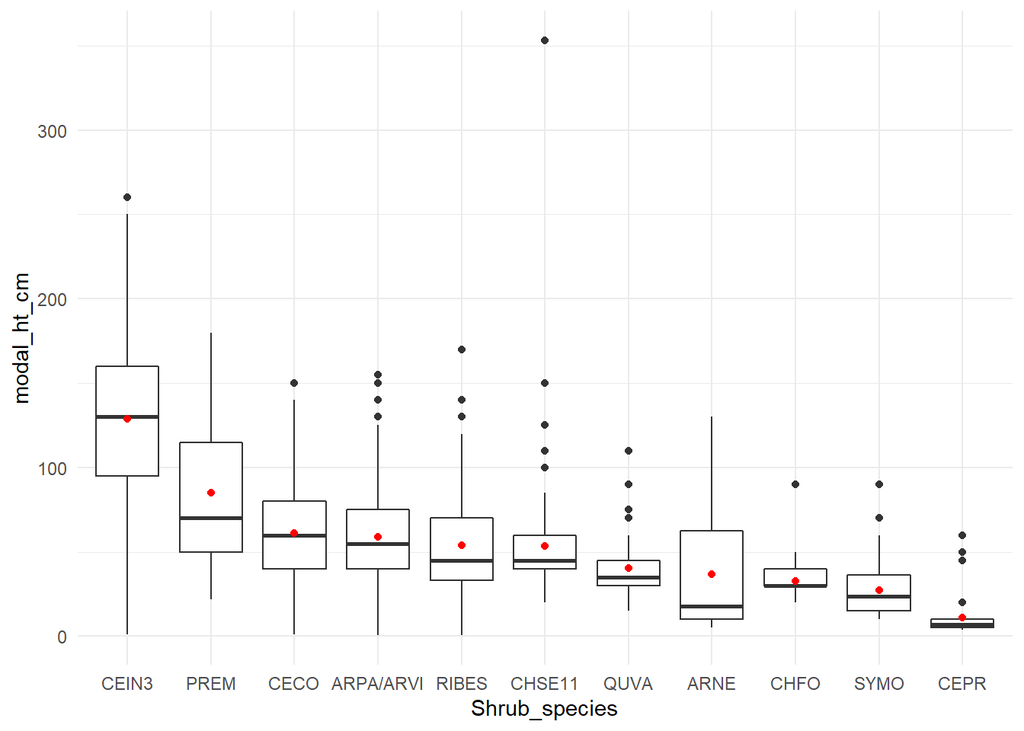

```r
welch_all %>%
  filter(years_since_fire %in% c(5:8)) %>%
  mutate(Shrub_species = ifelse(Shrub_species %in% c("ARPA6", "ARVI"), "ARPA/ARVI", Shrub_species)) %>%
  group_by(Shrub_species) %>%
  mutate(mean_ht = mean(modal_ht_cm)) %>%
  ungroup() %>%
  mutate(Shrub_species = fct_reorder(Shrub_species, desc(mean_ht))) %>%
ggplot()+
  geom_boxplot(aes(x = Shrub_species, y = modal_ht_cm))+
  theme_minimal()+
  geom_point(aes(x = Shrub_species, y = mean_ht), col = "red")
```

# Save CEIN height data for use in simulations

```r
welch_CEIN_hts <- welch_all %>%
  filter(years_since_fire %in% c(5:8)) %>%
  filter(Shrub_species == "CEIN3") %>%
  mutate(shrubarea3 = sqrt(Cover*modal_ht_cm)) %>%
  dplyr::select(years_since_fire, Regen_Plot, Cover, modal_ht_cm, Fire, Shrub_species) %>%
  distinct()

welch_CEIN_hts
```

```
## # A tibble: 228 x 6
##    years_since_fire Regen_Plot Cover modal_ht_cm Fire  Shrub_species
##               <dbl> <chr>      <dbl>       <dbl> <chr> <chr>
##  1                5 PWR0900182  10           190 POWER CEIN3
##  2                5 PWR0900172  13            95 POWER CEIN3
##  3                5 PWR0900163   5           150 POWER CEIN3
##  4                5 PWR0900149   0.5          75 POWER CEIN3
##  5                5 PWR0900148  39           220 POWER CEIN3
##  6                5 PWR0900146   0.5          60 POWER CEIN3
##  7                5 PWR0900161   5           200 POWER CEIN3
##  8                5 PWR0900086  10           130 POWER CEIN3
##  9                5 PWR0900115   5           200 POWER CEIN3
## 10                5 PWR0900070   1            55 POWER CEIN3
## # ... with 218 more rows
```

```r
save(welch_CEIN_hts, file = "../../../../data/welch_CEIN_hts.Rdata")
```

## Repeat for CEIN COVER, limiting it to plots where CEIN is dominant

```r
welch_subset <- welch_all %>%
  filter(years_since_fire %in% c(5:8))
```

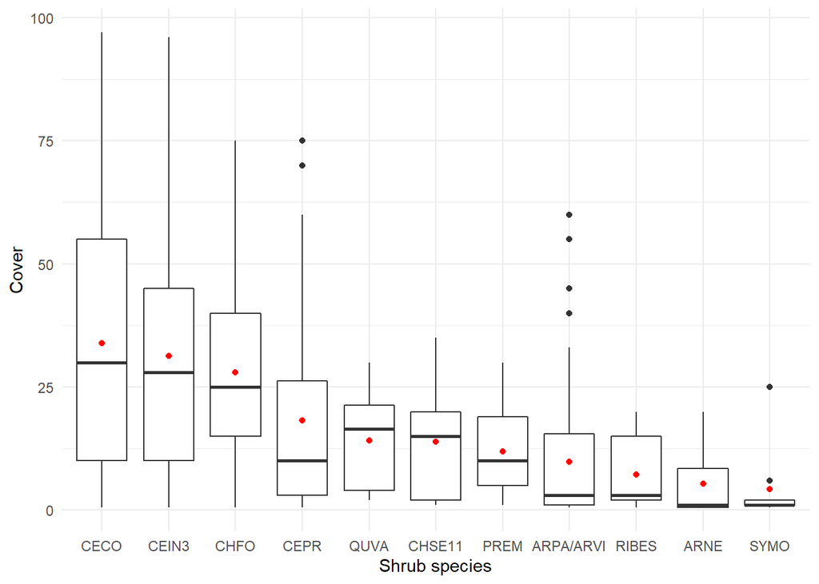

```r
welch_all_summary <- welch_subset %>%
  ungroup() %>%
  group_by(Regen_Plot) %>%
  filter(Cover == max(Cover)) %>%
  mutate(shrubarea = Cover*modal_ht_cm) %>%
  group_by(Regen_Plot) %>%
  filter(shrubarea == max(shrubarea)) %>%
  mutate(Shrub_species = ifelse(Shrub_species %in% c("ARPA6", "ARVI"), "ARPA/ARVI", Shrub_species)) %>%
  group_by(Shrub_species) %>%
  mutate(mean_cov = mean(Cover)) %>%
  ungroup() %>%
  mutate(Shrub_species = fct_reorder(Shrub_species, desc(mean_cov)))

ggplot(welch_all_summary)+
  geom_boxplot(aes(x = Shrub_species, y = Cover))+
  theme_minimal()+
  geom_point(aes(x = Shrub_species, y = mean_cov), col = "red")+
  xlab("Shrub species")
```

```r
ggsave(file = "../../../../results/figures/Simulations/welch_cein_ceco_ht_compare.png", width = 8)
```

### Make sure there’s only one row per plot/Species combo

```r
welch_all_summary %>%
  group_by(Regen_Plot, Species) %>%
  filter(n()>1)
```

```
## # A tibble: 2 x 25
## # Groups:   Regen_Plot, Species [1]
##   years_since_fire Year_meas `Year of Fire` Shrub_species Regen_Plot Cover
##              <dbl>     <dbl>          <dbl> <fct>         <chr>      <dbl>
## 1                5      2013           2008 CHSE11        CUB1300199    20
## 2                5      2013           2008 QUVA          CUB1300199    20
## # ... with 19 more variables: modal_ht_cm <dbl>, ID.x <dbl>, Fire <chr>,
## #   Date <dttm>, FIRE_SEV <dbl>, seed_tree_dist_m <dbl>, ID.y <dbl>,
## #   Count_total <dbl>, Type <chr>, Species <chr>, num_dead <dbl>,
## #   seed_veg_plant <chr>, tallest_age <dbl>, tallest_ht_cm <dbl>,
## #   tallest_lastyr_cm <dbl>, Remarks <chr>, number_sprouts <lgl>,
## #   shrubarea <dbl>, mean_cov <dbl>
```

Those species don’t matter for the species combo breakdown so I’m going to leave it as is.

# Look at overall combinations of shrub and tree species across Welch data

## Count the plots included in this analysis to translate later results to per area densities

```r
plots <- length(unique(welch_subset$Regen_Plot))
save(plots, file = "../../../../results/data/n_plots_welch_subset.Rdata")
```

```r
welch_ratios <- welch_all_summary %>%
  group_by(Shrub_species, Species) %>%
  summarize(plots = n(), trees = sum(na.omit(Count_total))) %>%
  filter(Species %in% c("ABCO", "PIPO"))
welch_ratios
```

```
## # A tibble: 18 x 4
## # Groups:   Shrub_species [11]
##    Shrub_species Species plots trees
##    <fct>         <chr>   <int> <dbl>
##  1 CECO          ABCO       29   148
##  2 CECO          PIPO       27    57
##  3 CEIN3         ABCO       21   129
##  4 CEIN3         PIPO       34   116
##  5 CHFO          ABCO        1     2
##  6 CHFO          PIPO       20    95
##  7 CEPR          PIPO        4    24
##  8 QUVA          ABCO        1     2
##  9 QUVA          PIPO        1     1
## 10 CHSE11        ABCO        6   105
## 11 CHSE11        PIPO        4    17
## 12 PREM          PIPO        1     1
## 13 ARPA/ARVI     ABCO        9    18
## 14 ARPA/ARVI     PIPO       18    90
## 15 RIBES         ABCO        5    28
## 16 ARNE          ABCO        5    40
## 17 ARNE          PIPO        3     3
## 18 SYMO          PIPO        1     2
```

# Save thise proportions to use in simulation initialization

## reformat so it’s compatible with my shrub data

### Which shrub species are most common?

```r
welch_ratios %>%
  summarize(sum(plots), trees = sum(trees)) %>%
  arrange(desc(trees))
```

```
## # A tibble: 11 x 3
##    Shrub_species `sum(plots)` trees
##    <fct>                <int> <dbl>
##  1 CEIN3                   55   245
##  2 CECO                    56   205
##  3 CHSE11                  10   122
##  4 ARPA/ARVI               27   108
##  5 CHFO                    21    97
##  6 ARNE                     8    43
##  7 RIBES                    5    28
##  8 CEPR                     4    24
##  9 QUVA                     2     3
## 10 SYMO                     1     2
## 11 PREM                     1     1
```

### Take out CHFO because it’s not in my American River fire, it’s not in the top 4 species ny # trees in the Welch data, and it would be difficult to initialize without knowing who establishes under it

```r
welch_ratios <- welch_ratios %>%
  filter(Shrub_species != "CHFO")
```

```r
main_spp <- c("LIDE", "ARPA", "CECO", "CEIN", "CHSE", "Other")

welch_ratios <- welch_ratios %>%
  ungroup() %>%
  mutate(Shrub_species = case_when(
    Shrub_species == "CEIN3" ~ "CEIN",
    Shrub_species == "ARPA/ARVI" ~ "ARPA",
    Shrub_species == "CHSE11" ~ "CHSE",
    !Shrub_species %in% main_spp ~ "Other",
    TRUE ~ as.character(Shrub_species)
  )) %>%
  group_by(Shrub_species, Species) %>%
  summarize(trees = sum(trees)) %>%
  ungroup() %>%
  mutate(prop = trees/sum(trees))


welch_ratios
```

```
## # A tibble: 10 x 4
##    Shrub_species Species trees   prop
##    <chr>         <chr>   <dbl>  <dbl>
##  1 ARPA          ABCO       18 0.0230
##  2 ARPA          PIPO       90 0.115
##  3 CECO          ABCO      148 0.190
##  4 CECO          PIPO       57 0.0730
##  5 CEIN          ABCO      129 0.165
##  6 CEIN          PIPO      116 0.149
##  7 CHSE          ABCO      105 0.134
##  8 CHSE          PIPO       17 0.0218
##  9 Other         ABCO       70 0.0896
## 10 Other         PIPO       31 0.0397
```

```r
save(welch_ratios, file = "../../../../results/coefficients/welch_ratios.Rdata")
```

# Look at tallest trees

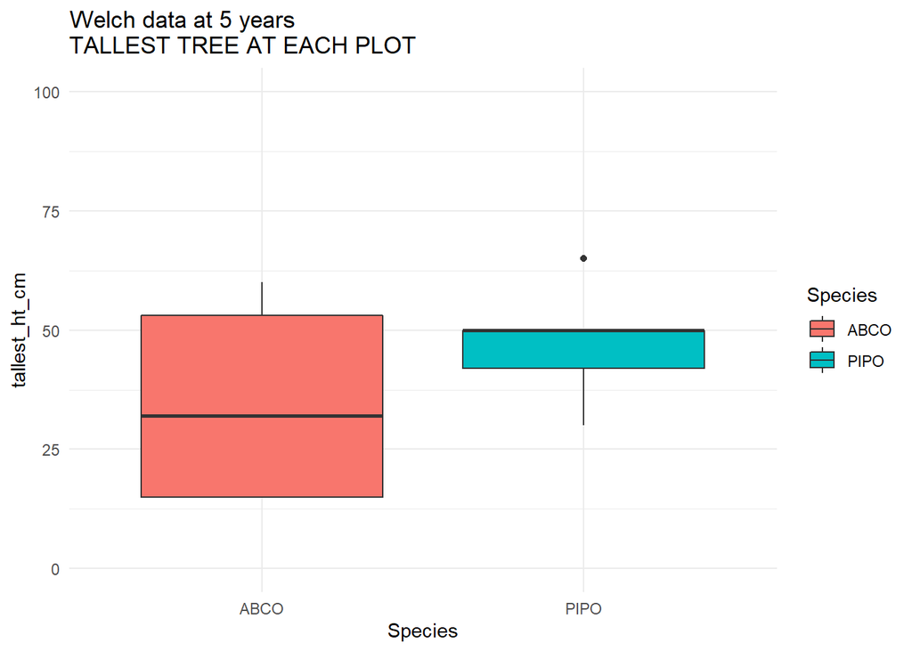

```r
welch_tallest <- welch %>%
  filter(Species %in% c("PIPO", "ABCO")) %>%
  ggplot()+
  geom_boxplot(aes(x = Species, y = tallest_ht_cm, fill = Species))+
  theme_minimal()+
  ylim(c(0,100))+
  ggtitle("Welch data at 5 years\nTALLEST TREE AT EACH PLOT")
welch_tallest
```

# In American River COmplex FIre

```r
me <- me %>%
  filter(Fire == "AMRC")
```

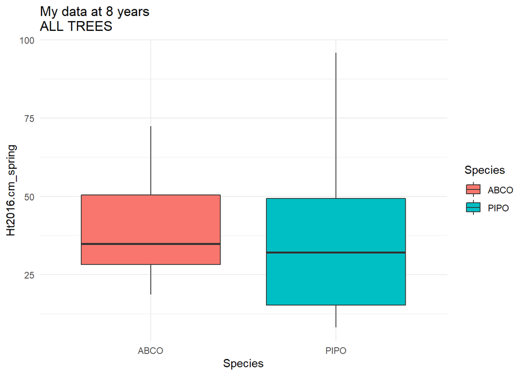

```r
me_tallest <- ggplot(me)+
  geom_boxplot(aes(x = Species, y = Ht2016.cm_spring, fill = Species))+
  theme_minimal()+
  ggtitle("My data at 8 years\nALL TREES")
me_tallest
```

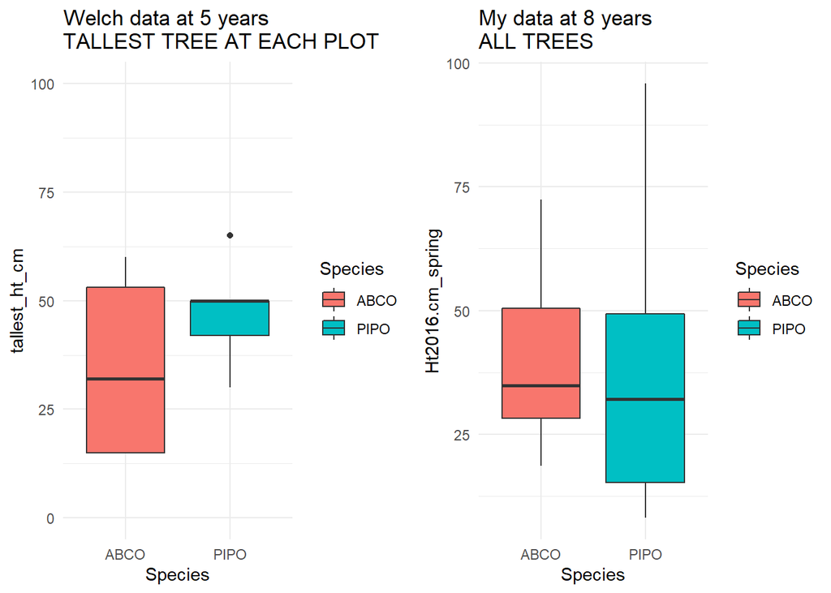

```r
grid.arrange(welch_tallest, me_tallest, ncol = 2)
```

# Now compare shrub height between the two

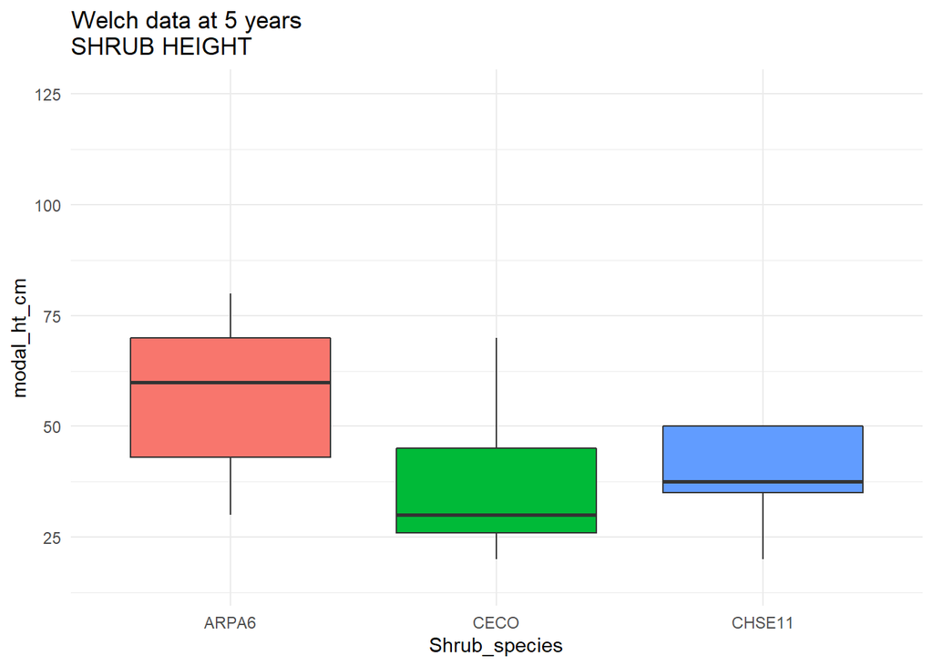

```r
welch_shr_ht <- ggplot(welch %>% filter(Shrub_species %in% c("ARPA6", "CECO", "CHSE11")))+
  geom_boxplot(aes(x = Shrub_species, y = modal_ht_cm, fill = Shrub_species))+
  theme_minimal()+
  ylim(15, 125)+
  ggtitle("Welch data at 5 years\nSHRUB HEIGHT")+
  theme(legend.position = "none")
welch_shr_ht
```

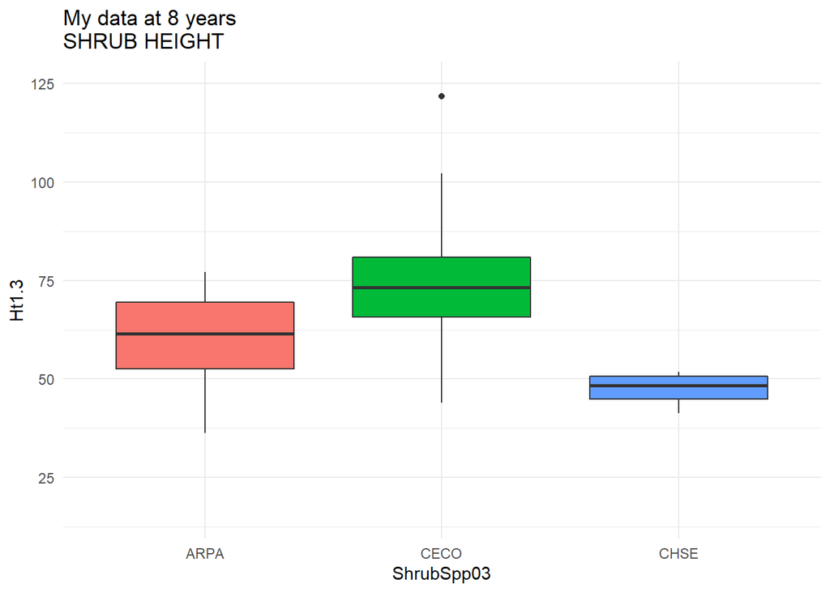

```r
me_shr_ht <- ggplot(me %>% filter(ShrubSpp03 %in% c("ARPA", "CECO", "CHSE")))+
  geom_boxplot(aes(x = ShrubSpp03, y = Ht1.3, fill = ShrubSpp03))+
  theme_minimal()+
  ylim(15, 125)+
  ggtitle("My data at 8 years\nSHRUB HEIGHT")+
  theme(legend.position = "none")
me_shr_ht
```

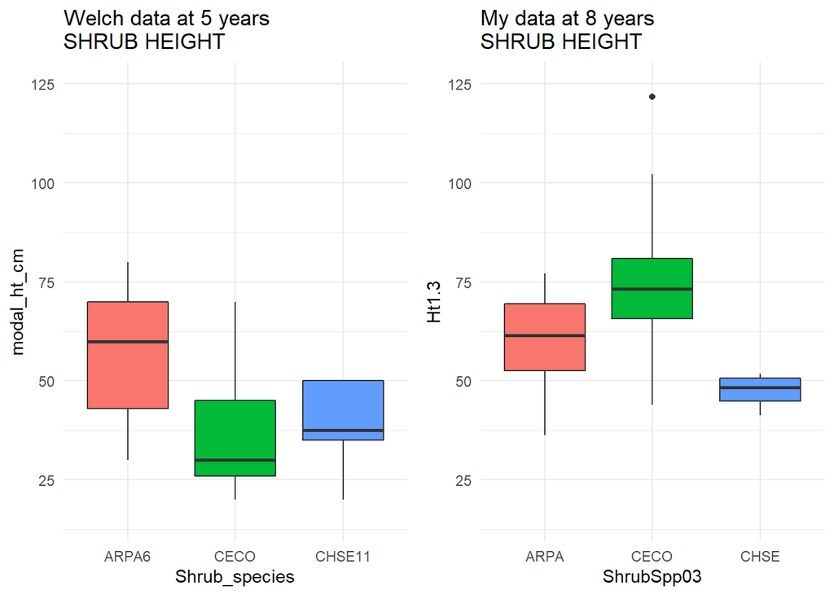

```r
grid.arrange(welch_shr_ht, me_shr_ht, ncol = 2)
```